# Spatial Interpolation Overview

Julie Wisch

6/10/2021

## Introduction

The EPA manages a variety of monitoring sites at the locations shown below. The goal of this project is to generate estimates of common air pollutants across the greater St. Louis area. In order to do this, we will apply inverse distance weighted interpolation.

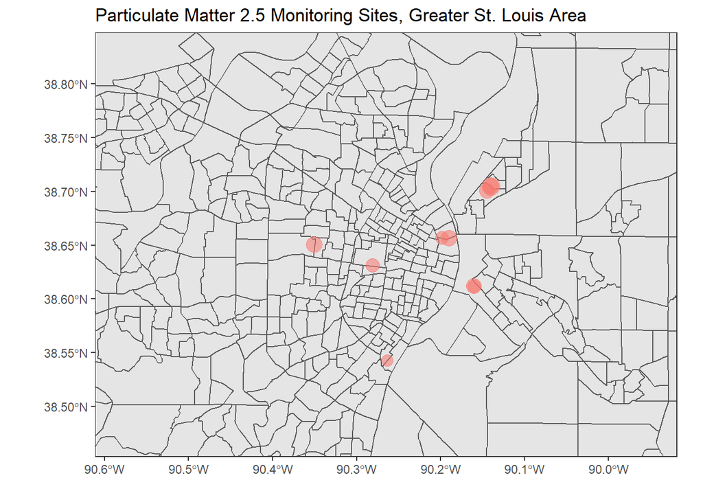

### Spatial Interpolation for Visualization

Here we visualize the interpolated estimates of PM2.5 across the metro area. Note that when you generate points for visualization, you must use an evenly spaced grid. When you are calculating points as estimates for individual participants, you do not have to supply a grid. you can just use points.

The code for interpolation is quite simple, but you have to do a decent amount of manipulation of the spatial data structures to be able to use them. This code is shown below.

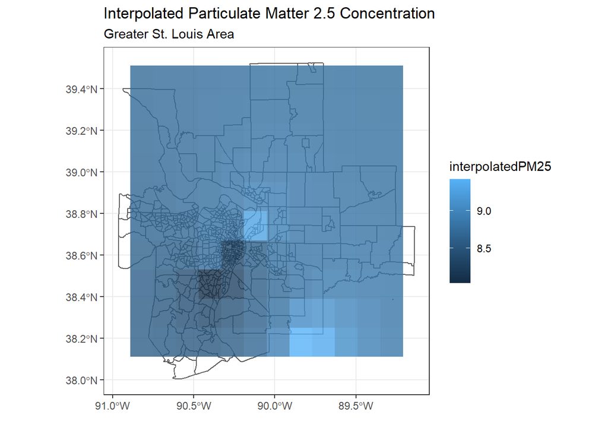

```r
EPA <- EPA_Annual[EPA_Annual$Year == 2017,] #Trimming to a single year
coordinates(EPA) <- ~ SITE_LONGITUDE + SITE_LATITUDE #converting spatial df
coordinates(address_df) <- ~ Lon + Lat

metro_region_coordinates <- data.frame(unlist(metro_region$geometry))

grd <- makegrid(address_df, n = 1000) #generating grid for plotting
colnames(grd) <- c("x", "y")


grd <- grd[!duplicated(grd),]
# Next, convert the grid to `SpatialPoints` and subset these points by the polygon.
grd_pts <- SpatialPoints(
  coords      = grd,
  proj4string = CRS(proj4string(EPA))
)

#Actual Interpolation Starts Here
lzn.idw <- idw(log(PM25_concentration) ~ 1,  EPA,
                    newdata = grd_pts) #inverse distance weighted interpolation
lzn.idw$interpolatedPM25 <- exp(lzn.idw$var1.pred) #returning to original units
```

### Spatial Interpolation for Point Estimates

Instead of generating smoothed estimates over a grid, we can generate point estimates for a list of lat/long coordinates of interest. Here we do that, then display the estimates for those points of interest within census tracts. The code required to do this is very similar to that displayed in the chunk above, so we omit it here and instead just show the result.

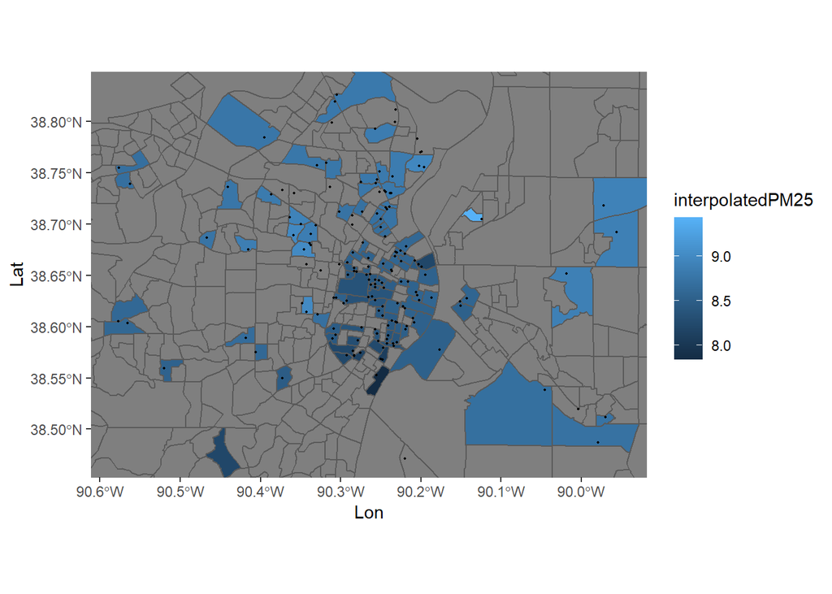